# Ecologia de peces

Kenneth Roy Cabrera Torres

30 de agosto de 2016

## Contextualización

Datos de la tesis doctoral de Verneaux (1973)

Verneaux, J. (1973) Cours d’eau de Franche-Comté (Massif du Jura). Recherches écologiques sur le réseau hydrographique du Doubs. Essai de biotypologie. Thèse d’état, Besançon. 1–257

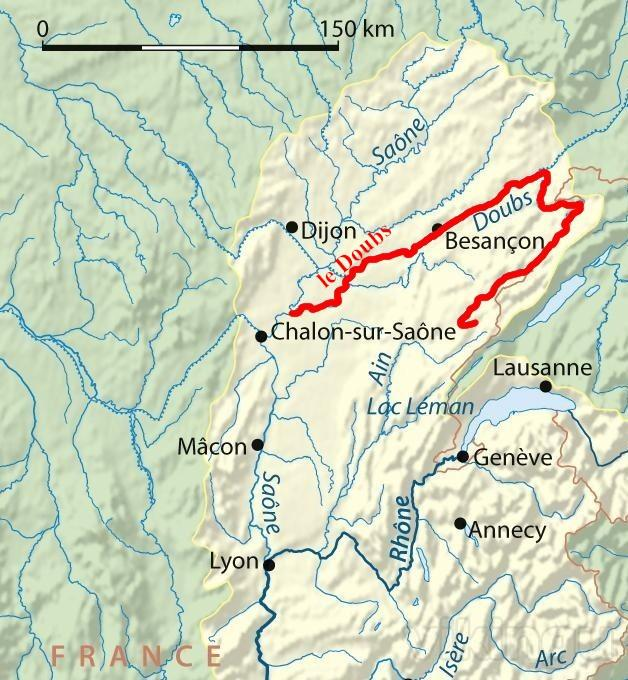

[figure not shown]

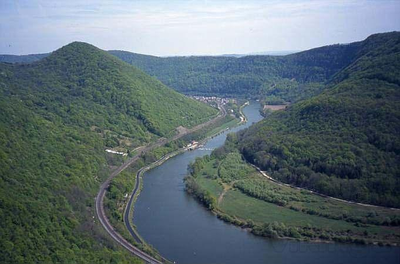

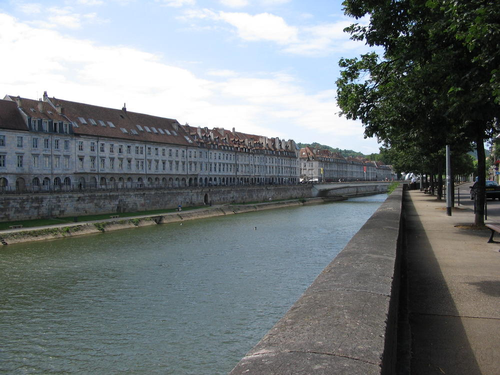

La tesis propone el uso de las especies de peces para caracterizar las zonas ecológicas a lo largo de rios y quebradas de Europa. Él mostró que las comunidades de peses son buenos indicadores biológicos para estos cuerpos de agua. A partir del nacimiento propuso una topología en cuatro zonas, y las designó de acuerdo a las características de las especies como:

- Zona de la trucha (Trout zone)
- Zona del tímalo (Grayling zone)
- Zona del barbo (Barbel zone)
- Zona de la brema (Bream zone)

Las condiciones ecológicas correspondientes, con mucha variación entre los rios, varía desde agua relativamente pristinas, bien oxigendadas y oligotróficas hasta eutróficas y sin oxígeno.

Los datos se tomaron en 30 lugares a lo largo del río Doubs. Este río corre cerca de la frontera franco-suiza al borde del macizo del Jura.

## Listado de las bases de datos.

- La base de datos de **peces** tienen las abundancias de 27 especies de peces. Las abundancias están reescalada a una medida semicuantitativa de 1 a 5.
- La base de datos **ambientales** tiene 11 variable ambientales relacionadas con la hidrología, la geomorfología y la química del rio.
- La base de datos de **localidades** tiene las coordenadas planas de cada uno de los sitios de muestreo.
- La base de datos **nombre de especies** tiene los códigos, los nombres científicos, los nombres en inglés y en francés de las 27 especies reconocidas en el estudio.
- La base de datos **Nombres de variables ambientales** tiene los códigos de las variables ambientales, la designación completa y las unidades de cada variable.

## Lectura de las bases de datos

```r
ambient<-read.csv2("ambientales.csv",enc="latin1",row.names=1)
peces<-read.csv2("peces.csv",enc="latin1",row.names=1)
locs<-read.csv2("localidades.csv",enc="latin1",row.names=1)
nomEspec<-read.csv2("nombresdeespecies.csv",enc="latin1")
nomVarAmbient<-read.csv2("Nombresdevariablesambientales.csv",enc="latin1")
```

## Análisis descriptivo univariado

### Abundancia de peces.

Despliegue de la base de datos. (Este procedimiento no es recomendado para grandes base de datos.)

```r
peces
```

```
##    Cogo Satr Phph Neba Thth Teso Chna Chto Lele Lece Baba Spbi Gogo Eslu
## 1     0    3    0    0    0    0    0    0    0    0    0    0    0    0
## 2     0    5    4    3    0    0    0    0    0    0    0    0    0    0
## 3     0    5    5    5    0    0    0    0    0    0    0    0    0    1
## 4     0    4    5    5    0    0    0    0    0    1    0    0    1    2
## 5     0    2    3    2    0    0    0    0    5    2    0    0    2    4
## 6     0    3    4    5    0    0    0    0    1    2    0    0    1    1
## 7     0    5    4    5    0    0    0    0    1    1    0    0    0    0
## 8     0    0    0    0    0    0    0    0    0    0    0    0    0    0
## 9     0    0    1    3    0    0    0    0    0    5    0    0    0    0
## 10    0    1    4    4    0    0    0    0    2    2    0    0    1    0
## 11    1    3    4    1    1    0    0    0    0    1    0    0    0    0
## 12    2    5    4    4    2    0    0    0    0    1    0    0    0    0
## 13    2    5    5    2    3    2    0    0    0    0    0    0    0    0
## 14    3    5    5    4    4    3    0    0    0    1    1    0    1    1
```

[output cut: 47 more lines]

### Resumen de la base de datos de peces

```r
summary(peces)
```

```
##       Cogo           Satr           Phph            Neba
##  Min.   :0.00   Min.   :0.00   Min.   :0.000   Min.   :0.000
##  1st Qu.:0.00   1st Qu.:0.00   1st Qu.:0.000   1st Qu.:1.000
##  Median :0.00   Median :1.00   Median :3.000   Median :2.000
##  Mean   :0.50   Mean   :1.90   Mean   :2.267   Mean   :2.433
##  3rd Qu.:0.75   3rd Qu.:3.75   3rd Qu.:4.000   3rd Qu.:4.000
##  Max.   :3.00   Max.   :5.00   Max.   :5.000   Max.   :5.000
##       Thth           Teso             Chna          Chto
##  Min.   :0.00   Min.   :0.0000   Min.   :0.0   Min.   :0.0000
##  1st Qu.:0.00   1st Qu.:0.0000   1st Qu.:0.0   1st Qu.:0.0000
##  Median :0.00   Median :0.0000   Median :0.0   Median :0.0000
##  Mean   :0.50   Mean   :0.6333   Mean   :0.6   Mean   :0.8667
##  3rd Qu.:0.75   3rd Qu.:0.7500   3rd Qu.:1.0   3rd Qu.:2.0000
##  Max.   :4.00   Max.   :5.0000   Max.   :3.0   Max.   :4.0000
##       Lele            Lece            Baba            Spbi
##  Min.   :0.000   Min.   :0.000   Min.   :0.000   Min.   :0.0
##  1st Qu.:0.000   1st Qu.:1.000   1st Qu.:0.000   1st Qu.:0.0
##  Median :1.000   Median :2.000   Median :0.000   Median :0.0
##  Mean   :1.433   Mean   :1.867   Mean   :1.433   Mean   :0.9
##  3rd Qu.:2.000   3rd Qu.:3.000   3rd Qu.:3.000   3rd Qu.:1.0
##  Max.   :5.000   Max.   :5.000   Max.   :5.000   Max.   :5.0
##       Gogo            Eslu            Pefl          Rham
##  Min.   :0.000   Min.   :0.000   Min.   :0.0   Min.   :0.0
##  1st Qu.:0.000   1st Qu.:0.000   1st Qu.:0.0   1st Qu.:0.0
##  Median :1.000   Median :1.000   Median :0.5   Median :0.0
##  Mean   :1.833   Mean   :1.333   Mean   :1.2   Mean   :1.1
##  3rd Qu.:3.750   3rd Qu.:2.000   3rd Qu.:2.0   3rd Qu.:2.0
##  Max.   :5.000   Max.   :5.000   Max.   :5.0   Max.   :5.0
##       Legi             Scer          Cyca             Titi
##  Min.   :0.0000   Min.   :0.0   Min.   :0.0000   Min.   :0.0
##  1st Qu.:0.0000   1st Qu.:0.0   1st Qu.:0.0000   1st Qu.:0.0
##  Median :0.0000   Median :0.0   Median :0.0000   Median :1.0
##  Mean   :0.9667   Mean   :0.7   Mean   :0.8333   Mean   :1.5
##  3rd Qu.:1.7500   3rd Qu.:1.0   3rd Qu.:1.0000   3rd Qu.:3.0
##  Max.   :5.0000   Max.   :5.0   Max.   :5.0000   Max.   :5.0
##       Abbr             Icme          Acce            Ruru
##  Min.   :0.0000   Min.   :0.0   Min.   :0.000   Min.   :0.0
##  1st Qu.:0.0000   1st Qu.:0.0   1st Qu.:0.000   1st Qu.:0.0
##  Median :0.0000   Median :0.0   Median :0.000   Median :1.0
##  Mean   :0.8667   Mean   :0.6   Mean   :1.267   Mean   :2.1
##  3rd Qu.:1.0000   3rd Qu.:0.0   3rd Qu.:2.000   3rd Qu.:5.0
##  Max.   :5.0000   Max.   :5.0   Max.   :5.000   Max.   :5.0
##       Blbj            Alal          Anan
##  Min.   :0.000   Min.   :0.0   Min.   :0.00
##  1st Qu.:0.000   1st Qu.:0.0   1st Qu.:0.00
##  Median :0.000   Median :0.0   Median :0.00
##  Mean   :1.033   Mean   :1.9   Mean   :0.90
##  3rd Qu.:1.750   3rd Qu.:5.0   3rd Qu.:1.75
##  Max.   :5.000   Max.   :5.0   Max.   :5.00
```

### Conteo de los casos para cada clase de abundancia

```r
(ab <- table(unlist(peces)))
```

```
##
##   0   1   2   3   4   5
## 435 108  87  62  54  64
```

```r
ab <- data.frame(ab)
names(ab) <- c("Caso","Frecuencia")
```

### Diagrama de barras de los conteos de abundancia

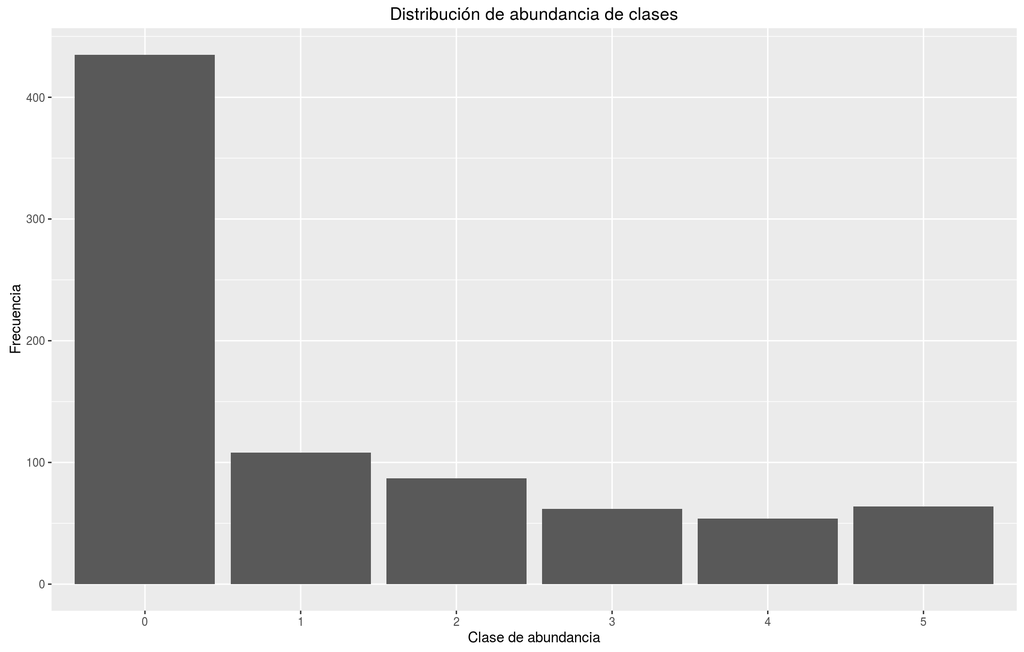

```r
require(ggplot2)
barras <- ggplot(data.frame(ab), aes(Caso,Frecuencia))
barras + geom_bar(stat = "identity") +
   ggtitle("Distribución de abundancia de clases") +
   xlab("Clase de abundancia")+
   ylab("Frecuencia")
```

### Mapa de localizaciones

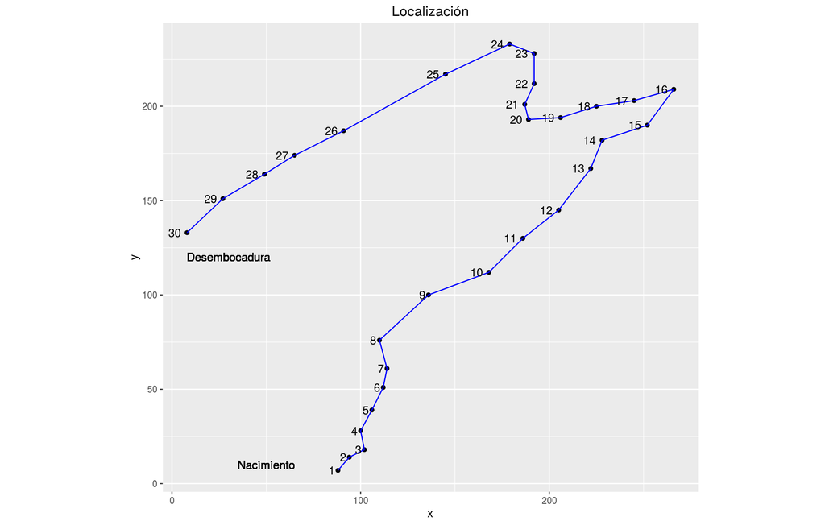

```r
require(ggplot2)
mapa <- ggplot(locs, aes(x, y))
mapa + geom_point() +
       coord_fixed() +
       geom_path(col = "blue") +
       geom_text(label = row.names(locs), hjust = 1.5) +
       geom_text(data = NULL, x=50, y = 10, label = "Nacimiento") +
       geom_text(data = NULL, x=30, y = 120, label = "Desembocadura") +
       ggtitle("Localización")
```

## Gráfica de cuatro especies

```r
seleccion1 <- subset(peces, select = c(Satr, Thth, Baba, Abbr))
seleccion1 <- data.frame(locs, seleccion1)
require(reshape2)
```

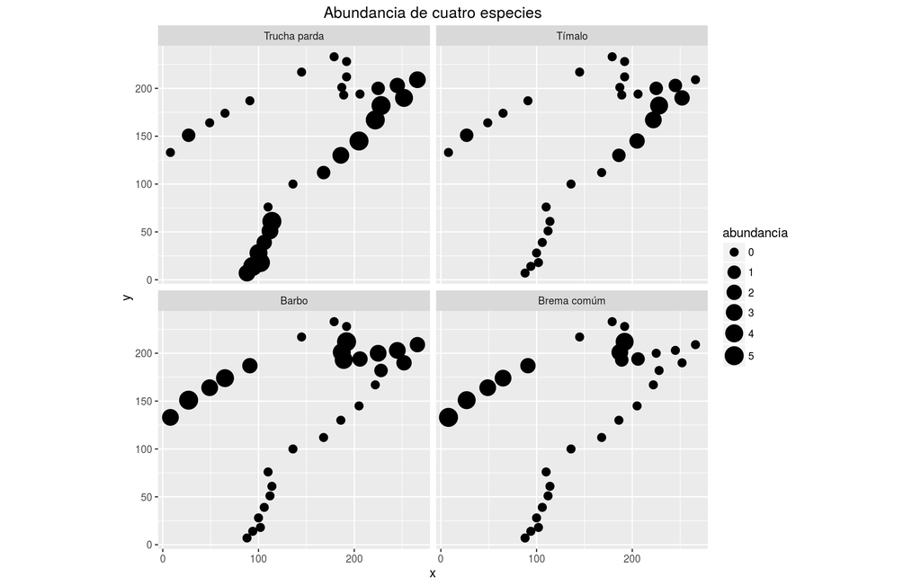

```r
seleccion2 <- melt(seleccion1, id.vars = c("x","y"), variable.name = "especie",
     value.name = "abundancia")
seleccion2$especie2 <- factor(seleccion2$especie,
                             labels = c("Trucha parda",
                             "Tímalo", "Barbo", "Brema comúm"))

require(ggplot2)
especs <- ggplot(seleccion2, aes(x, y, size = abundancia))
especs + geom_point() +
         coord_fixed() +
         facet_wrap( ~ especie2, ncol = 2) +
         scale_size_continuous(range = c(3,7)) +
         ggtitle("Abundancia de cuatro especies")
```

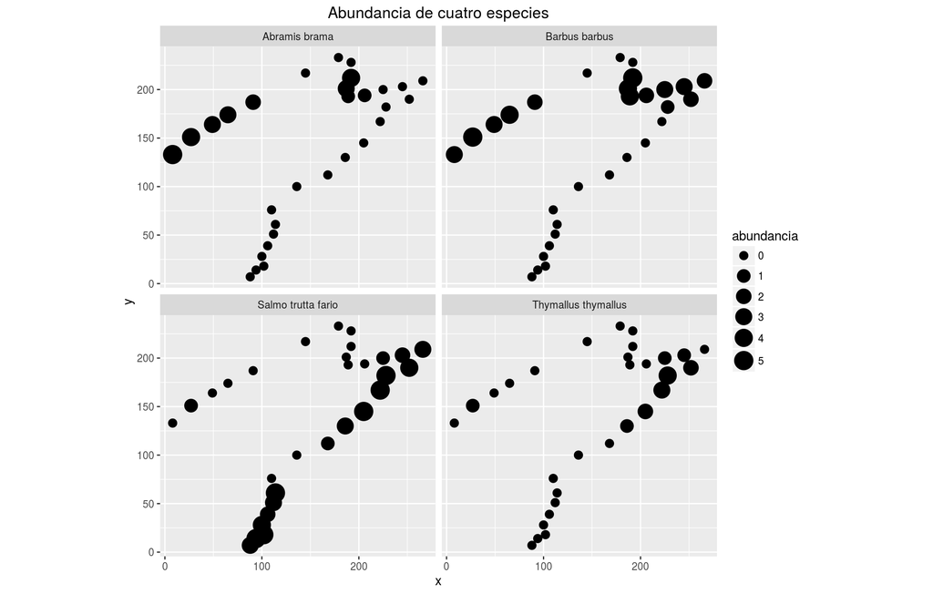

```r
seleccion3 <- merge(seleccion2, nomEspec, by.x = "especie", by.y = "code")

require(ggplot2)
especs <- ggplot(seleccion3, aes(x, y, size = abundancia))
especs + geom_point() +
         coord_fixed() +
         facet_wrap( ~ Scientific, ncol = 2) +
         scale_size_continuous(range = c(3,7)) +
         ggtitle("Abundancia de cuatro especies")
```

## Comparación de especies

```r
# Calcular el número de sitios donde cada especie está presente.
# Para sumar por columnas, el segundo argumento de la
# función apply() se establece en 2.
peces.pres <- apply(peces > 0, 2, sum)
# Ordenar el resultado en orden creciente
sort(peces.pres)
```

```
## Icme Cogo Thth Teso Abbr Blbj Chto Rham Scer Anan Chna Spbi Cyca Acce Legi
##    7    8    8    8    9   10   11   11   11   11   12   12   12   12   13
## Baba Alal Pefl Satr Titi Lele Eslu Ruru Phph Gogo Neba Lece
##   14   14   15   17   17   18   18   18   20   20   24   25
```

```r
# Calcular las frecuencias en porcentajes
peces.fRel <- 100*peces.pres/nrow(peces)
# Ordenar y redondear el resultado a un dígito
round(sort(peces.fRel), 1)
```

```
## Icme Cogo Thth Teso Abbr Blbj Chto Rham Scer Anan Chna Spbi Cyca Acce Legi
## 23.3 26.7 26.7 26.7 30.0 33.3 36.7 36.7 36.7 36.7 40.0 40.0 40.0 40.0 43.3
## Baba Alal Pefl Satr Titi Lele Eslu Ruru Phph Gogo Neba Lece
## 46.7 46.7 50.0 56.7 56.7 60.0 60.0 60.0 66.7 66.7 80.0 83.3
```

```r
# Convertir a base de datos
peces.fRel <- data.frame(distribucion = round(sort(peces.fRel), 1))
```

Gráfica de presencia de distribución (dispersión) de especies.

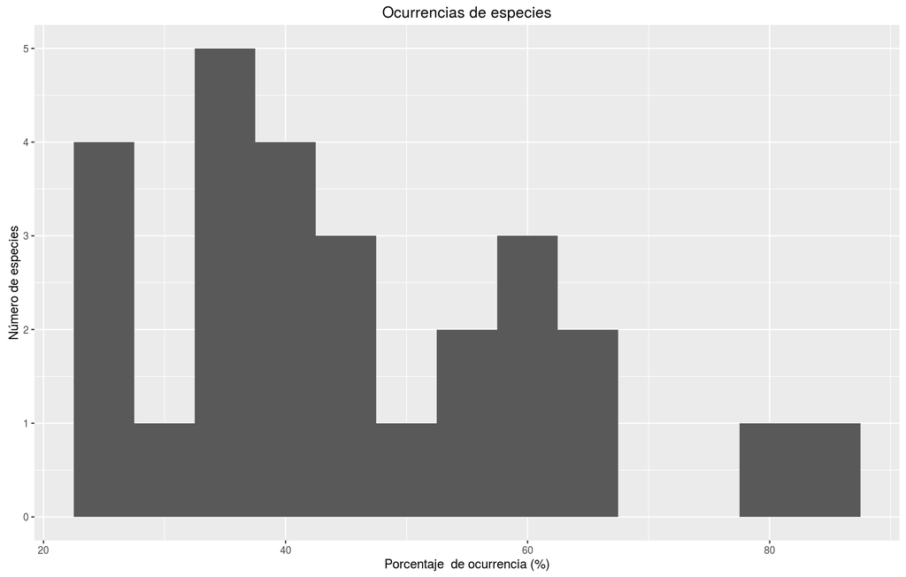

```r
require(ggplot2)
hist1 <- ggplot(peces.fRel, aes(distribucion))
hist1 + geom_histogram(binwidth = 5) +
        ggtitle("Ocurrencias de especies") +
        xlab("Porcentaje  de ocurrencia (%)") +
        ylab("Número de especies")
```

## Riqueza de especies por sitio

```r
# Cálculo del número de especies por sitio
# Para sumar por filas el segundo argumento de apply() se establece en 1
sit.pres <- apply(peces > 0, 1, sum)
# Ordenación de los resultados en orden creciente
sort(sit.pres)
```

```
##  8  1  2 23  3  7  9 10 11 12 13  4 24 25  6 14  5 15 16 26 30 17 20 22 27
##  0  1  3  3  4  5  5  6  6  6  6  8  8  8 10 10 11 11 17 21 21 22 22 22 22
## 28 18 19 21 29
## 22 23 23 23 26
```

Ejercicio: Consturir el mapa de riqueza.

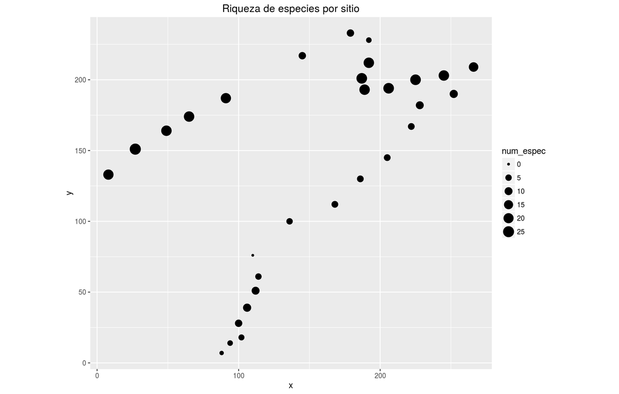